# Homework_4_SecondTry

Jacob Coggshall

2023-05-27

# Loading In Packages

```r
library(tidyverse)
library(naniar)
library(here)
library(janitor)
library(ggplot2)
library(dplyr)
library(gridExtra)
```

```r
fishdata <- read.csv(
  here("data", "ntl6_v12.csv"))|>
  clean_names()|>
  filter(spname == "TROUTPERCH") |>
  filter(!is.na(weight))
```

### Biological terms:

H0: Fish length does not predict fish weight for trout perch across all sample years. HA: Fish length predicts fish weight for trout perch across all sample years.

### Standard

Null hypothesis (H0): There is no significant relationship between fish length (L) and fish weight (W) for trout perch across all sample years.

Alternative hypothesis (HA): There is a significant relationship between fish length (L) and fish weight (W) for trout perch across all sample years.

### Mathmatical

H0: The coefficient of fish length in the linear regression model is equal to zero. HA: The coefficient of fish length in the linear regression model is not equal to zero.

# Checking missing variable

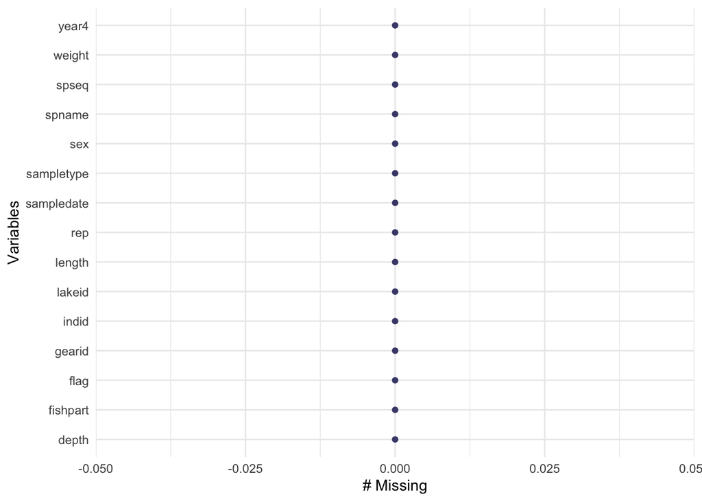

```r
gg_miss_var(fishdata)
```

The missing data is not relevant to our hypotheses because we have filtered out all the rows where there was no reading for the weight of trout perch. By removing the rows with missing weight values, we ensure that our analysis includes only complete data points, allowing us to examine the relationship between fish length and fish weight without the confounding effect of missing values.

```r
t_test_result <- t.test(fishdata$length, fishdata$weight)

t_test_result
```

```
##
##  Welch Two Sample t-test
##
## data:  fishdata$length and fishdata$weight
## t = 119.61, df = 317.21, p-value < 2.2e-16
## alternative hypothesis: true difference in means is not equal to 0
## 95 percent confidence interval:
##  78.81089 81.44704
## sample estimates:
## mean of x mean of y
## 85.517241  5.388276
```

```r
cor_result <- cor.test(fishdata$length, fishdata$weight)

print(cor_result)
```

```
##
##  Pearson's product-moment correlation
##
## data:  fishdata$length and fishdata$weight
## t = 35.789, df = 288, p-value < 2.2e-16
## alternative hypothesis: true correlation is not equal to 0
## 95 percent confidence interval:
##  0.8799624 0.9227135
## sample estimates:
##       cor
## 0.9035626
```

# Testing Linearity

```r
linear <- ggplot(data = fishdata, aes(x = length, y = weight)) +
  geom_point() +
  geom_smooth(method = "lm", se = TRUE) +
  labs(x = "Fish Length", y = "Fish Weight",
       title = "Plot of Fish Length vs. Fish Weight")
```

# Testing Normalilty

```r
# Create a histogram
histo <- ggplot(data = fishdata, aes(x = weight)) +
  geom_histogram(binwidth = 1, fill = "lightblue", color = "black") +
  labs(x = "Fish Weight", y = "Frequency",
       title = "Histogram of Fish Weight")

# Create a Q-Q plot
qq <- ggplot(data = fishdata, aes(sample = weight)) +
  stat_qq() +
  stat_qq_line() +
  labs(x = "Theoretical Quantiles", y = "Sample Quantiles",
       title = "Q-Q Plot of Fish Weight")
```

# Testing Homoscedasticity

```r
# Fit a linear regression model
lm_model <- lm(weight ~ length, data = fishdata)

# Extract the residuals and predicted values
residuals <- lm_model$residuals
predicted_values <- predict(lm_model)

# Create a data frame with predicted values and residuals
residual_df <- data.frame(Predicted = predicted_values, Residuals = residuals)

# Create a scatter plot of residuals against predicted values
scatter <- ggplot(data = residual_df, aes(x = Predicted, y = Residuals)) +
  geom_point() +
  labs(x = "Predicted Values", y = "Residuals",
       title = "Residuals vs. Predicted Values Plot")
```

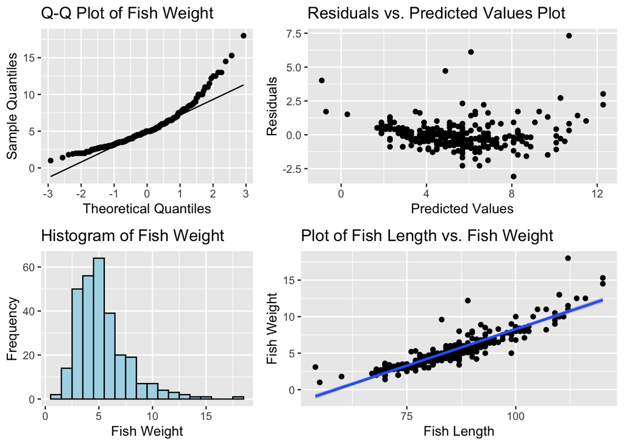

```r
# Load the necessary packages
library(gridExtra)

# Arrange the plots in a grid layout
full_grid <- grid.arrange(qq, scatter, histo, linear,ncol = 2, nrow = 2, widths = c(5, 7))
```

The scatter plot with a trendline shows the relationship between fish length and fish weight. By visually analyzing the plot, we can observe the general trend and determine that there is a positive or negative correlation between the two variables.

The scatter plot of residuals against predicted values shows the distribution of the residuals across the range of predicted values. By examining the plot, we can assess that there is no significant deviation in the residuals.

```r
summary(fishdata)
```

```
##     lakeid              year4       sampledate           gearid
##  Length:290         Min.   :1981   Length:290         Length:290
##  Class :character   1st Qu.:1991   Class :character   Class :character
##  Mode  :character   Median :1998   Mode  :character   Mode  :character
##                     Mean   :1998
##                     3rd Qu.:2006
##                     Max.   :2022
##     spname           sampletype            depth              rep
##  Length:290         Length:290         Min.   :-1.0000   Min.   : 1.000
##  Class :character   Class :character   1st Qu.:-1.0000   1st Qu.: 3.000
##  Mode  :character   Mode  :character   Median :-1.0000   Median : 4.000
##                                        Mean   :-0.9931   Mean   : 5.676
##                                        3rd Qu.:-1.0000   3rd Qu.: 8.000
##                                        Max.   : 1.0000   Max.   :19.000
##     indid               length           weight           sex
##  Length:290         Min.   : 54.00   Min.   : 1.000   Length:290
##  Class :character   1st Qu.: 78.00   1st Qu.: 3.625   Class :character
##  Mode  :character   Median : 85.00   Median : 5.000   Mode  :character
##                     Mean   : 85.52   Mean   : 5.388
##                     3rd Qu.: 92.00   3rd Qu.: 6.500
##                     Max.   :120.00   Max.   :18.000
##    fishpart            spseq               flag
##  Length:290         Length:290         Length:290
##  Class :character   Class :character   Class :character
##  Mode  :character   Mode  :character   Mode  :character
##
##
##
```

```r
# Fit a linear regression model
model <- lm(weight ~ length, data = fishdata)

# Print the model summary
summary(model)
```

```
##
## Call:
## lm(formula = weight ~ length, data = fishdata)
##
## Residuals:
##     Min      1Q  Median      3Q     Max
## -3.0828 -0.4862 -0.1830  0.4128  7.3191
##
## Coefficients:
##               Estimate Std. Error t value Pr(>|t|)
## (Intercept) -11.702476   0.481564  -24.30   <2e-16 ***
## length        0.199852   0.005584   35.79   <2e-16 ***
## ---
## Signif. codes:  0 '***' 0.001 '**' 0.01 '*' 0.05 '.' 0.1 ' ' 1
##
## Residual standard error: 1.057 on 288 degrees of freedom
## Multiple R-squared:  0.8164, Adjusted R-squared:  0.8158
## F-statistic:  1281 on 1 and 288 DF,  p-value: < 2.2e-16
```

```r
# Perform ANOVA
anova_result <- aov(weight ~ length, data = fishdata)

# Generate ANOVA table
anova_table <- summary(anova_result)

# Print the ANOVA table
print(anova_table)
```

```
##              Df Sum Sq Mean Sq F value Pr(>F)
## length        1 1432.3  1432.3    1281 <2e-16 ***
## Residuals   288  322.1     1.1
## ---
## Signif. codes:  0 '***' 0.001 '**' 0.01 '*' 0.05 '.' 0.1 ' ' 1
```

```r
# Perform ANOVA
anova_result <- aov(weight ~ length, data = fishdata)

# Extract ANOVA table
anova_table <- broom::tidy(anova_result) %>%
  select(df, sumsq, meansq, statistic, p.value) %>%
  clean_names()

# Format p-values without scientific notation
anova_table$p_value <- format.pval(anova_table$p_value, digits = 3)

# Rename columns
colnames(anova_table) <- c("Source", "DF", "Sum_Sq", "Mean_Sq", "F_Value", "P_Value")

# Print the summary table
print(anova_table)
```

```
## # A tibble: 2 × 5
##   Source    DF  Sum_Sq Mean_Sq F_Value
##    <dbl> <dbl>   <dbl>   <dbl> <chr>
## 1      1 1432. 1432.     1281. <2e-16
## 2    288  322.    1.12     NA  NA
```

```r
#summary
summary(fishdata)
```

```
##     lakeid              year4       sampledate           gearid
##  Length:290         Min.   :1981   Length:290         Length:290
##  Class :character   1st Qu.:1991   Class :character   Class :character
##  Mode  :character   Median :1998   Mode  :character   Mode  :character
##                     Mean   :1998
##                     3rd Qu.:2006
##                     Max.   :2022
##     spname           sampletype            depth              rep
##  Length:290         Length:290         Min.   :-1.0000   Min.   : 1.000
##  Class :character   Class :character   1st Qu.:-1.0000   1st Qu.: 3.000
##  Mode  :character   Mode  :character   Median :-1.0000   Median : 4.000
##                                        Mean   :-0.9931   Mean   : 5.676
##                                        3rd Qu.:-1.0000   3rd Qu.: 8.000
##                                        Max.   : 1.0000   Max.   :19.000
##     indid               length           weight           sex
##  Length:290         Min.   : 54.00   Min.   : 1.000   Length:290
##  Class :character   1st Qu.: 78.00   1st Qu.: 3.625   Class :character
##  Mode  :character   Median : 85.00   Median : 5.000   Mode  :character
##                     Mean   : 85.52   Mean   : 5.388
##                     3rd Qu.: 92.00   3rd Qu.: 6.500
##                     Max.   :120.00   Max.   :18.000
##    fishpart            spseq               flag
##  Length:290         Length:290         Length:290
##  Class :character   Class :character   Class :character
##  Mode  :character   Mode  :character   Mode  :character
##
##
##
```

The ANOVA table provides statistical information on the relationship between fish length and weight, indicating that there is a significant relationship between these variables (p-value < 2.2e-16). The summary object provides additional details such as the coefficient estimates, standard errors, t-values, and confidence intervals for the regression model. Both the ANOVA table and the summary object support the conclusion that fish length is a significant predictor of fish weight.

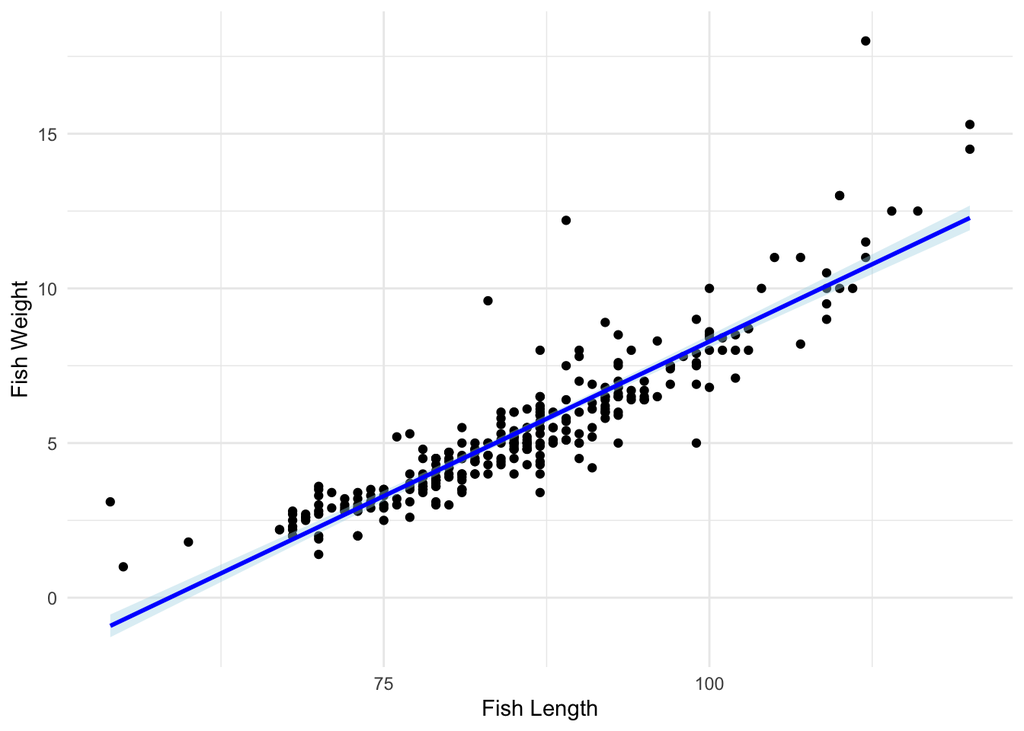

```r
# Create a scatter plot of the underlying data
scatter_plot <- ggplot(data = fishdata, aes(x = length, y = weight)) +
  geom_point() +
  labs(x = "Fish Length", y = "Fish Weight") +
  theme_minimal()

# Add model predictions and confidence intervals
model_plot <- scatter_plot +
  geom_smooth(method = "lm", se = TRUE, fill = "lightblue", color = "blue") +
  theme_minimal()

# Display the final plot
model_plot
```

Caption: Scatter plot showcasing the relationship between fish length and weight. The upward-sloping blue line indicates a positive correlation, suggesting that as the length of the fish increases, so does its weight. The shaded light blue areas surrounding the line represent the confidence intervals, indicating the range of plausible weight values for a given length. The plot suggests a strong and consistent association between fish length and weight, providing evidence for the predictive power of length in estimating the weight of trout and perch in the studied population.